# Introduction to Programming

# Solution

```r
# subset the observation wanted
flights_smpl <- filter(flights, carrier == "UA", year == 2013, month == 1)
# create the new variable
flights_smpl <- mutate(flights_smpl, arr_delay_rank = min_rank(arr_delay))
```

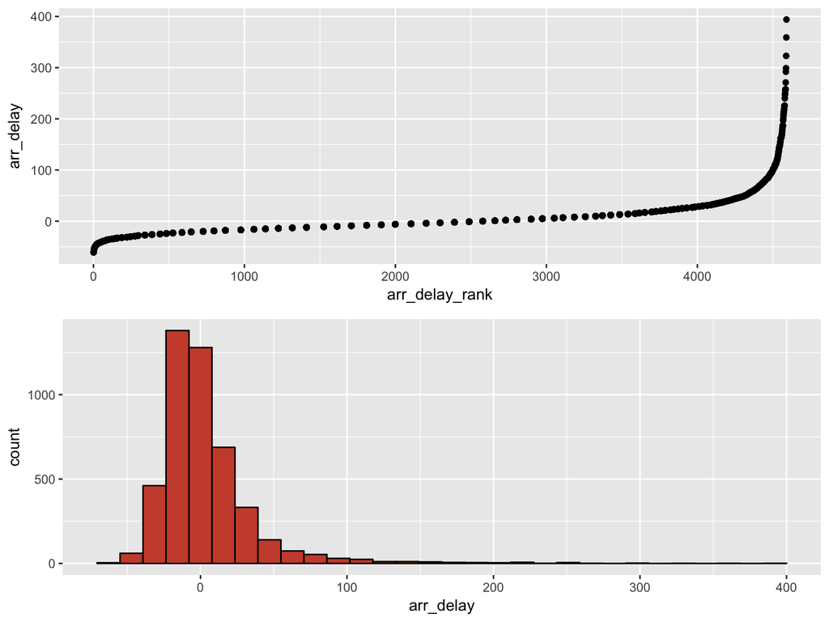

```r
ggplot(data = flights_smpl) +
  geom_point(aes(x = arr_delay_rank, y = arr_delay))
ggplot(data = flights_smpl) +
  geom_histogram(aes(x = arr_delay), fill = "tomato3", color = "black")
```

# Summary statistics

# `summarize()` and `group_by()`

- `summarize()` collapses a data frame to a single row

```r
# creates a new tibble with two columns: delay_m and delay_sd
summarize(flights, delay_m = mean(dep_delay, na.rm = T), delay_sd = sd(dep_delay, na.rm = T))
```

```
## # A tibble: 1 x 2
##   delay_m delay_sd
##     <dbl>    <dbl>
## 1    12.6     40.2
```

- `group_by()`: changes the unit of analysis from the complete dataset to individual groups

```r
# creates a new tibble that gives the mean and sd by month
by_month <- group_by(flights, year, month)
summarize(by_month, delay_m = mean(dep_delay, na.rm = T), delay_sd = sd(dep_delay, na.rm = T))
```

```
## # A tibble: 12 x 4
## # Groups:   year [?]
##     year month delay_m delay_sd
##    <int> <int>   <dbl>    <dbl>
##  1  2013     1   10.0      36.4
##  2  2013     2   10.8      36.3
##  3  2013     3   13.2      40.1
##  4  2013     4   13.9      43.0
##  5  2013     5   13.0      39.4
##  6  2013     6   20.8      51.5
##  7  2013     7   21.7      51.6
##  8  2013     8   12.6      37.7
##  9  2013     9    6.72     35.6
## 10  2013    10    6.24     29.7
## 11  2013    11    5.44     27.6
## 12  2013    12   16.6      41.9
```

# Combining multiple operations

# Motivation

- Suppose we want to explore the relationship between the distance and average delay for each location. Need to
  1. count the number of flights going to this location (*always good practice to count the number of observation per group*)
  2. compute the average distance
  3. compute the average delay
  4. subset the data to focus on the location with more than 20 observations & exclude Hawai

```r
# distinguish the different location
by_dest <- group_by(flights, dest)
# step 1, 2, 3
delay   <- summarize(by_dest, count = n(),
                              dist  = mean(distance, na.rm = T),
                              delay = mean(arr_delay, na.rm = T))
# step 4
delay   <- filter(delay, count > 20, dest != "HNL")
```

# Motivation

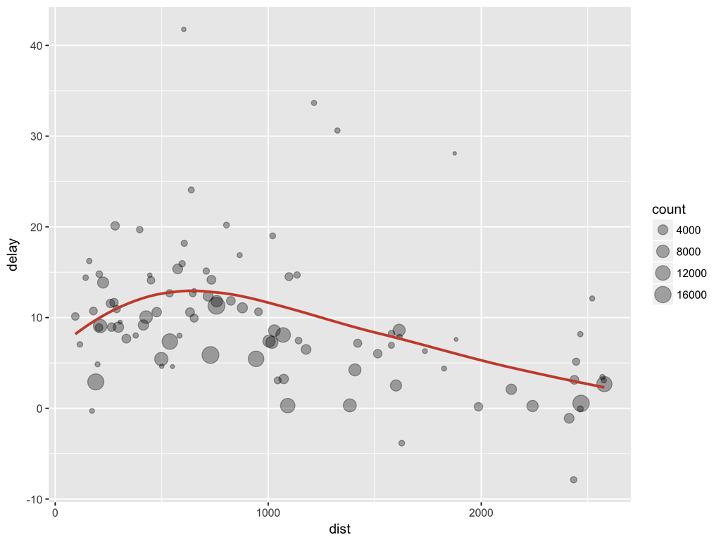

```r
ggplot(data = delay, mapping = aes(x = dist, y = delay)) +
  geom_point(aes(size = count), alpha = 1/3) +
  geom_smooth(se = FALSE, color = "tomato3")
```

# Pipe: the life saver

- In the code above, lots of unnecessary intermediary steps

```r
delays <- flights        %>%
          group_by(dest) %>%
          summarize(count = n(), dist = mean(distance, na.rm = T), delay = mean(arr_delay, na.rm = T)) %>%
          filter(count > 20, dest != "HNL")
```

- `%>%`: pipe instruction, that can be read as “then”

# Your turn

- Using the Lahman package that contains data on every major league baseball player, plot the skill of the batter (measured by the batting average) against the number of opportunities to hit the ball. You need:
  1. load the package
  2. transform it into a tibble (help provided below)
  3. compute, by player (identified by `playerID`), their batting average (i.e., the number of time they hit the ball, `H`, divided by the number of time they tried, `AB`), and the number of opportunities they had (again, `AB`)
  4. plot the result
  5. explain the result, and why there might be an endogeneity issue

```r
# to transform the data in a tibble, run
batting <- as_tibble(Lahman::Batting)
```

# Solution

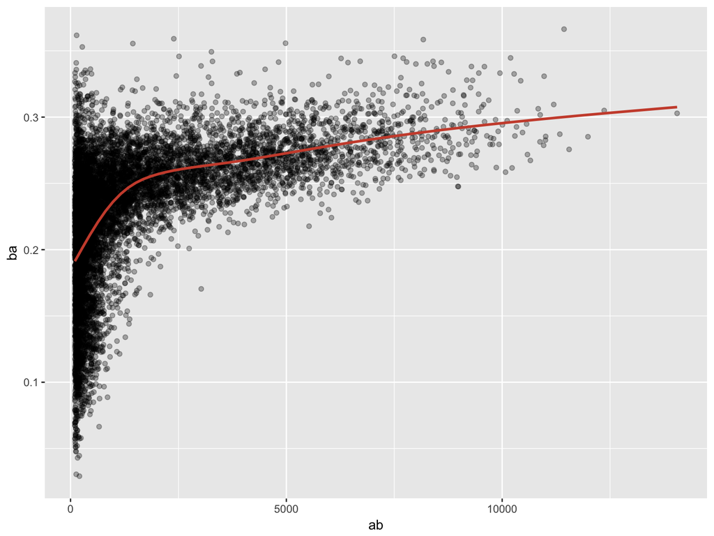

```r
# require(Lahman)
batting <- as_tibble(Lahman::Batting)
# create a data frame with the aggregated observation
batters <- batting            %>%
           group_by(playerID) %>%
           summarize(ba = sum(H, na.rm = T) / sum(AB, na.rm = T),
                     ab = sum(AB, na.rm = T)) %>%
           filter(ab > 100)
# plot the result
ggplot(batters, mapping = aes(x = ab, y = ba)) +
  geom_point(alpha = 0.3) +
  geom_smooth(color = "tomato3",se = FALSE)
```